# Temperature Comparisons

Mallory Barnes

September 25, 2018

### Diurnal Temperature Cycles

RED is Surface Temperature, calculated from radiometer data and modeled emissivity. BLUE is air temperature, measured at the flux towers.

I’ve compared the diurnal temperature cycle for estimated Surface Temperature vs. Air Temperature in both winter and summer

#### Morgan Monroe State Forest

Diurnal temperature signal for winter (January 2008) and summer (July 2008)

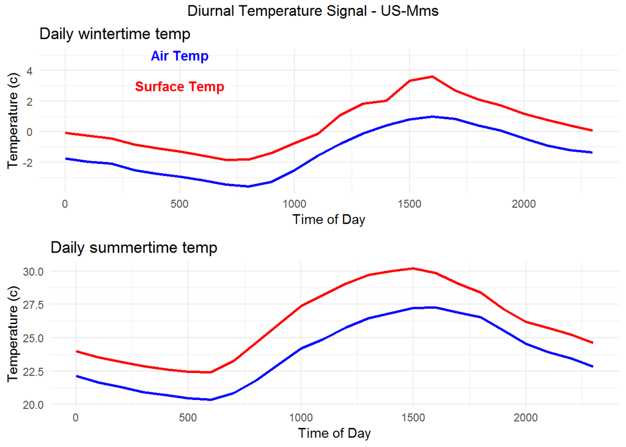

#### Duke Forest

Diurnal temperature signal for winter (January 2008) and summer (July 2008)

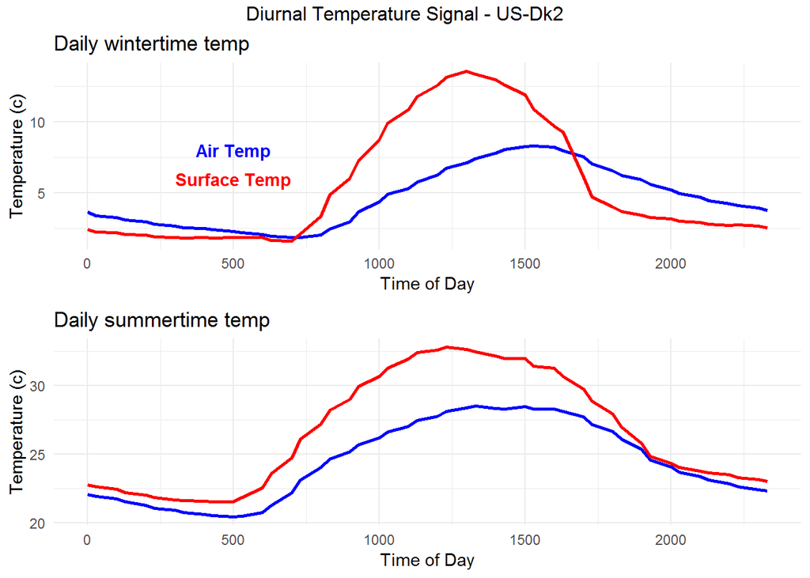

#### Duke Grassland

Diurnal temperature signal for winter (January 2008) and summer (July 2008)

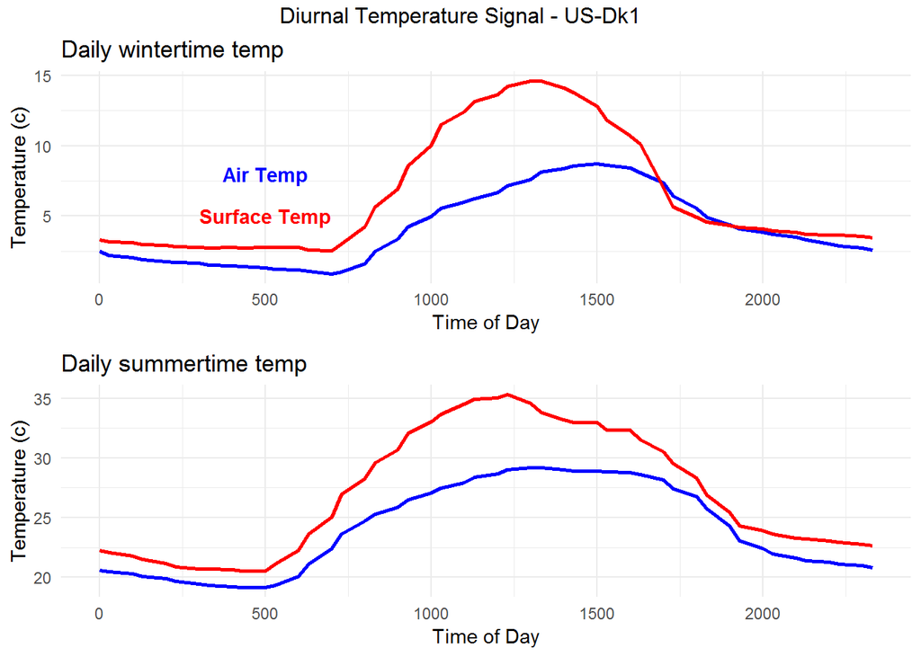

### Daily Temperature data

##### Summary Figures

Morgan Monroe State Forest:

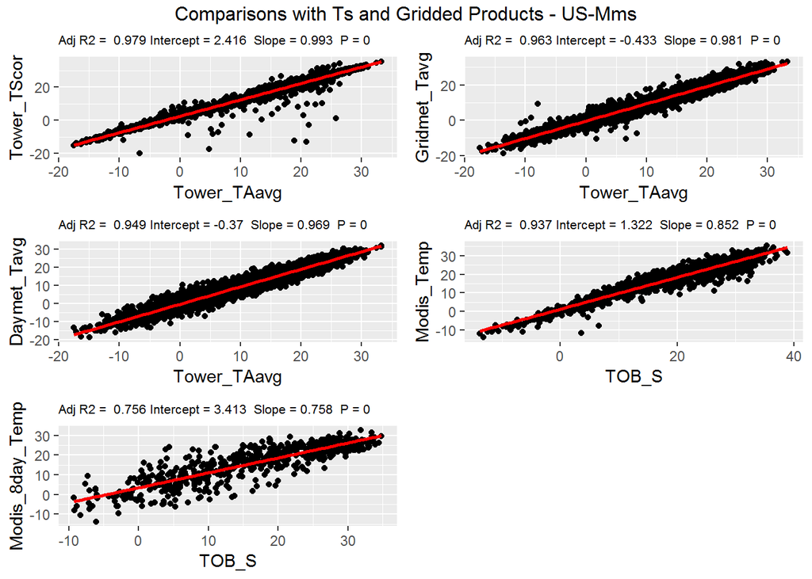

Duke Forest:

- Good agreement between air and surface temperature, surface temperature is consistently warmer, less so than at MMSF.
- Daymet is well correlated to tower air temperature, but Gridmet is not predicting tower air temperature well at all.
- Modis data had better coverage, bias is improved, but correlation isn’t great.

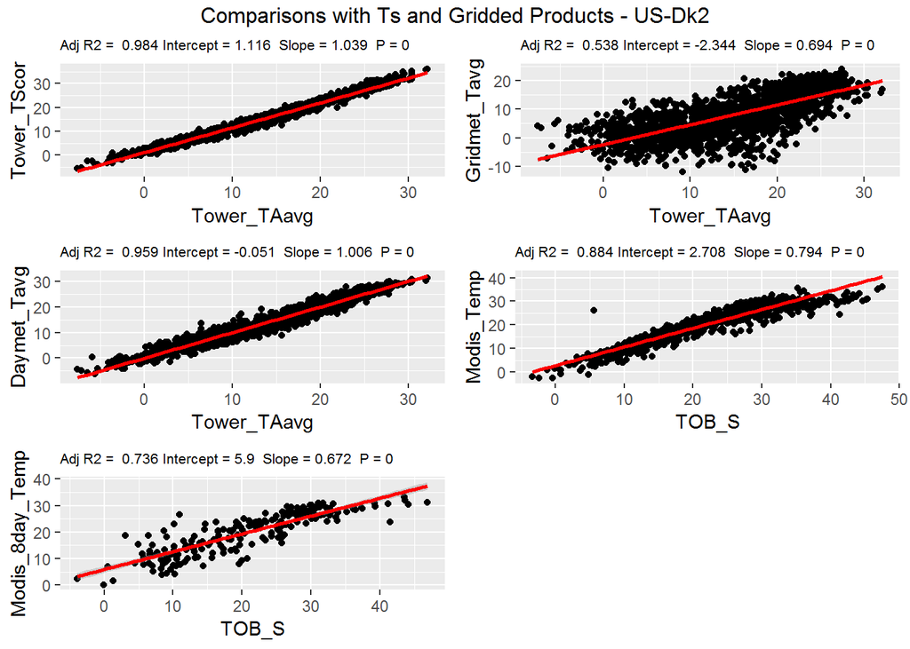

Duke Grassland:

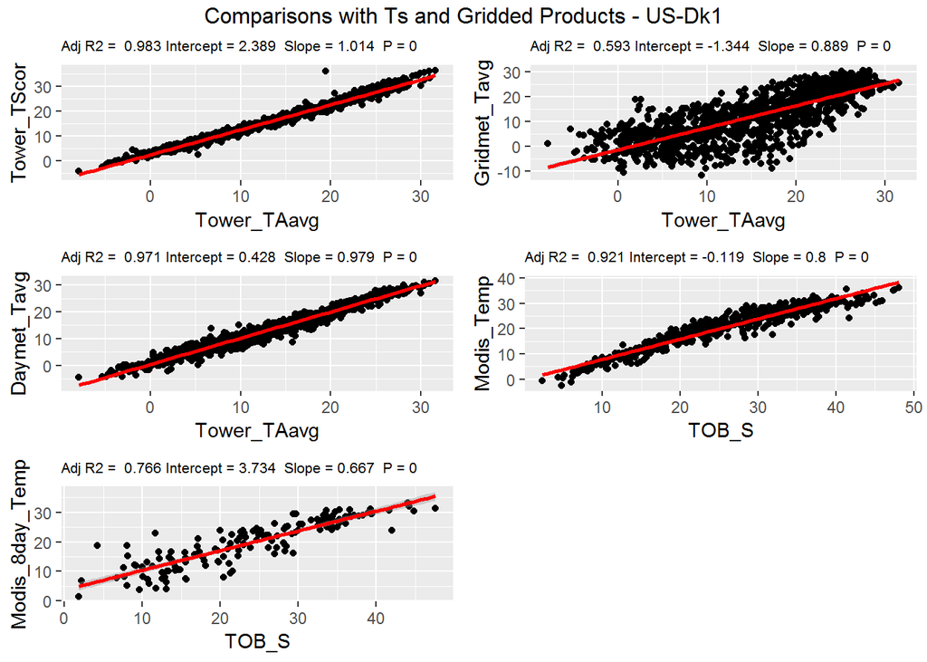

#### Morgan Monroe State Forest Daily surface and air temperature, and annual signals for 2008 *Surface temeperature consistently warmer than air temperature, but good agreement.

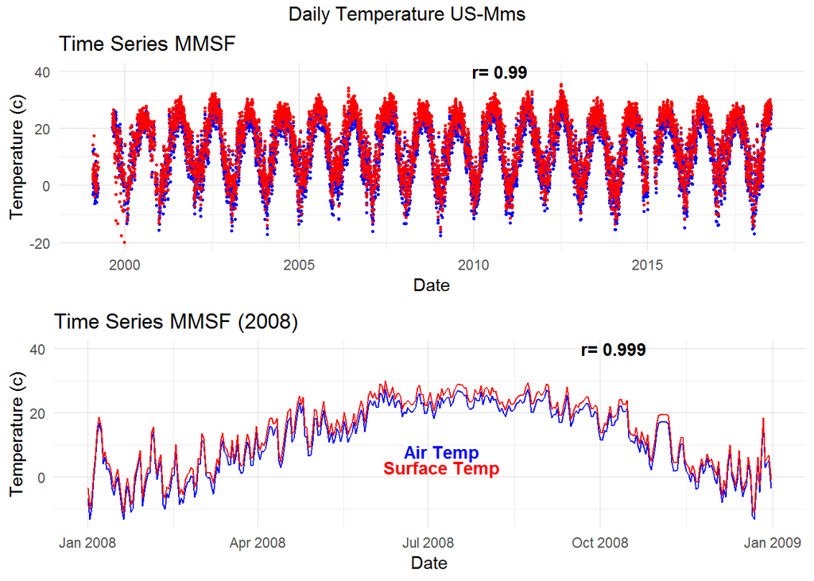

#### Duke Forest

Daily surface and air temperature (all) for 2007 Surface temeperature consistently warmer than air temperature, but good agreement.

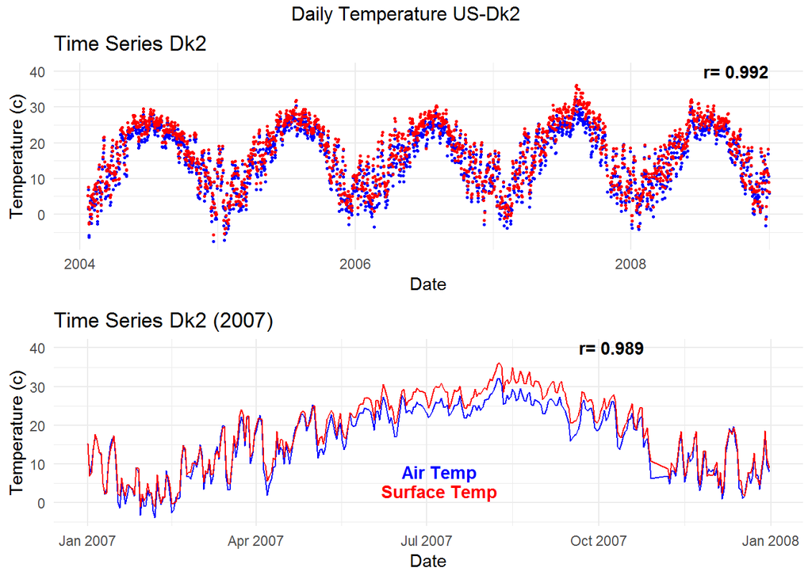

#### Duke Grassland Daily surface and air temperature (all) for 2007 Surface temeperature consistently warmer than air temperature, but good agreement.

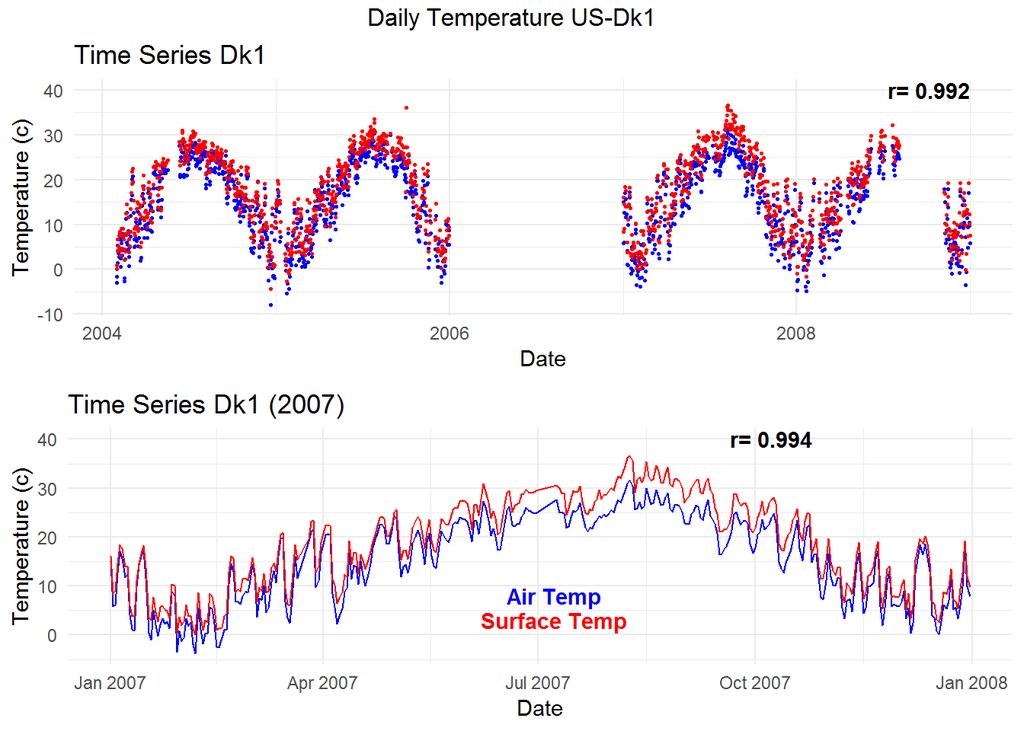

### Comparisons with gridded datasets

Comparing average daily temperature from tower air and surface temperature, Gridmet, Daymet, MODIS Land Surface temperature.

#### Morgan Monroe

Comparisons for Morgan Monroe State Forest

Daymet: Good relationship overall

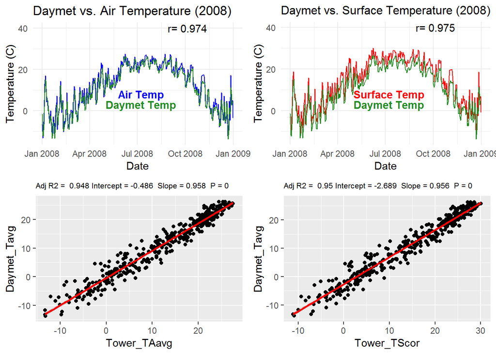

Gridmet: Good relationship overall

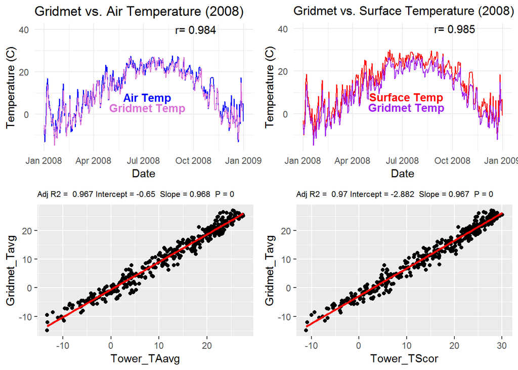

MODIS LST: Very few data points

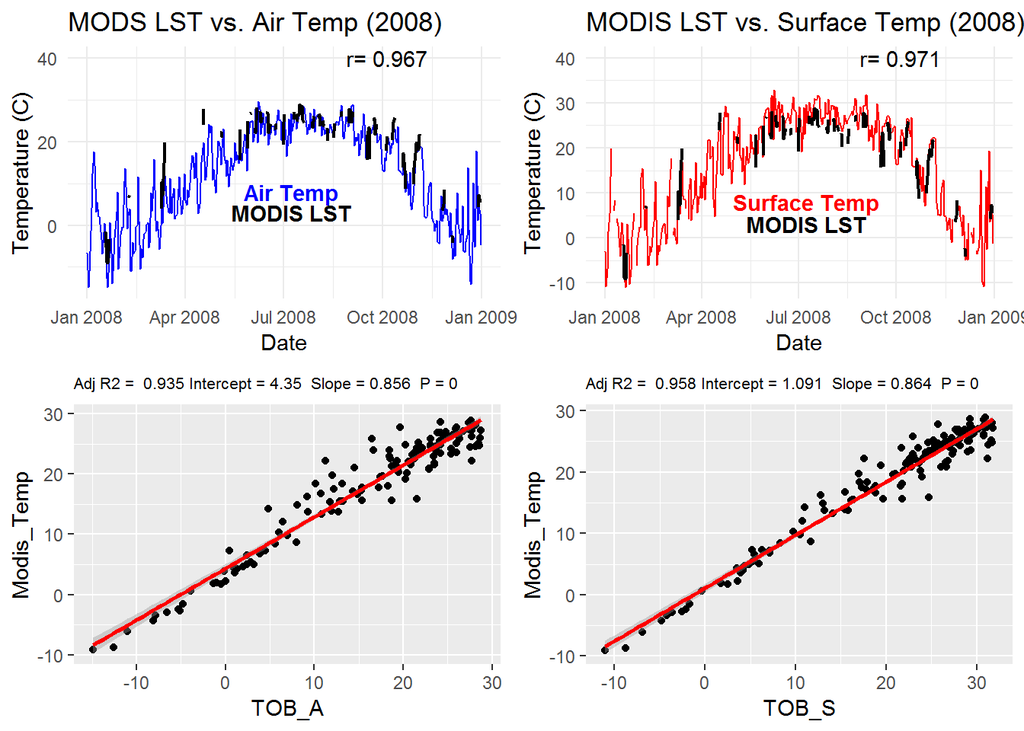

#### Duke Forest

Comparisons for Duke Forest

Daymet: Good relationship

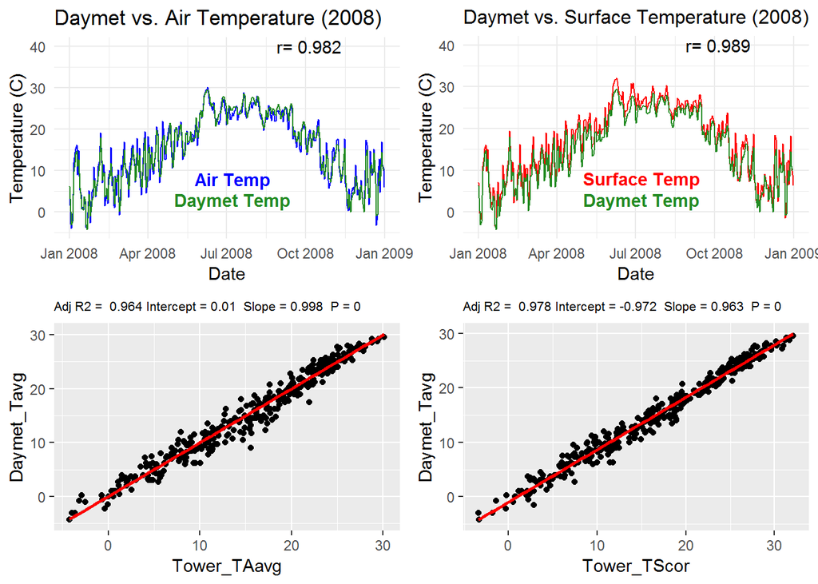

Gridmet:Worse relationship and consistently underestimates temperature

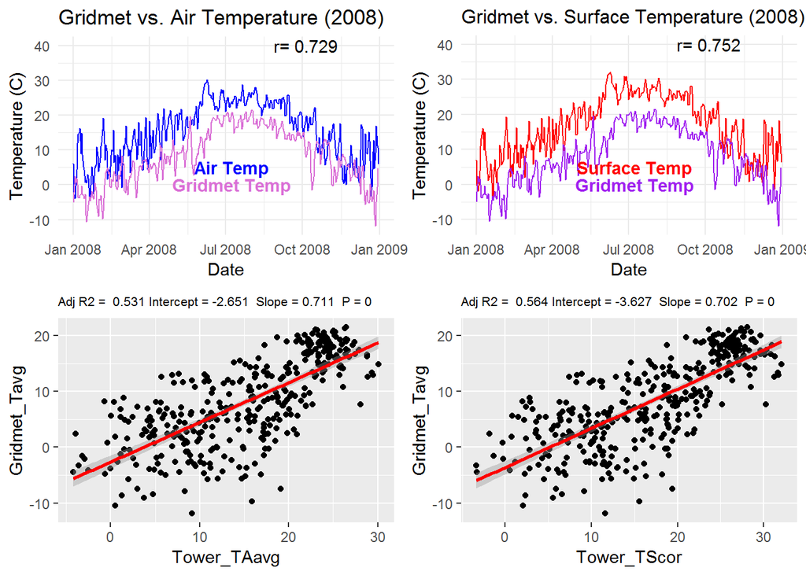

MODIS LST: Bias is much better, but relationship as clean as I’d like

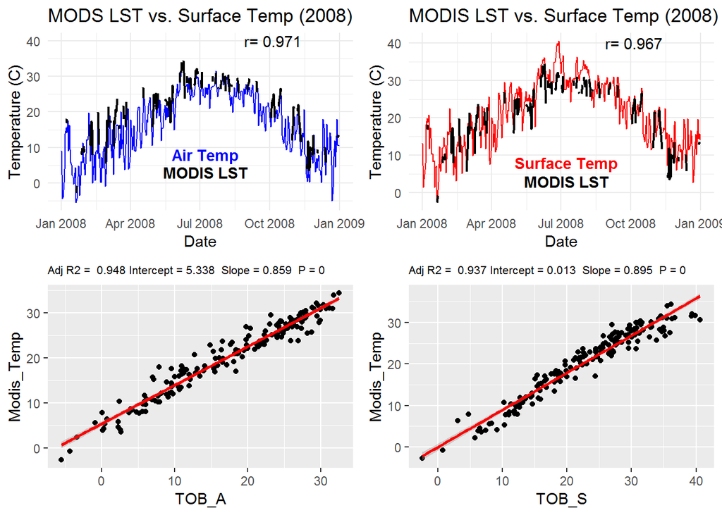

#### Duke Grassland

Comparisons for Duke Grassland Daymet: Strong Relationship

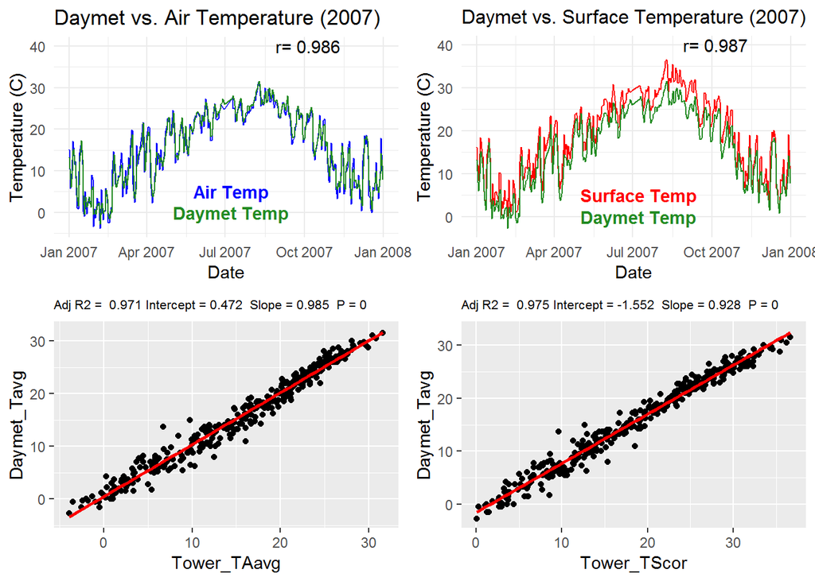

Gridmet: not as clean but bias is acceptable

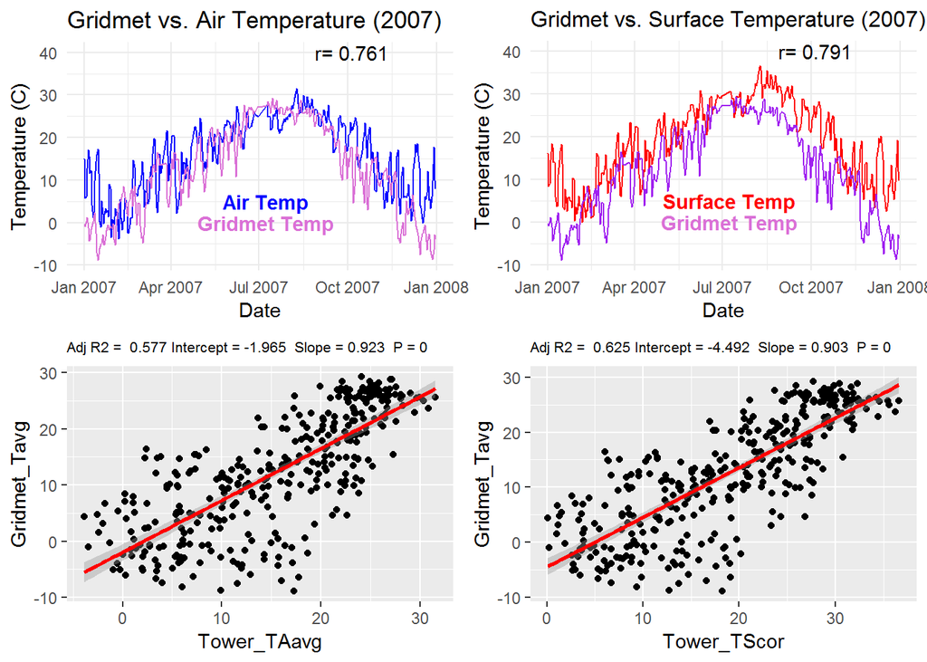

MODIS LST looks pretty good!

[figure not shown]

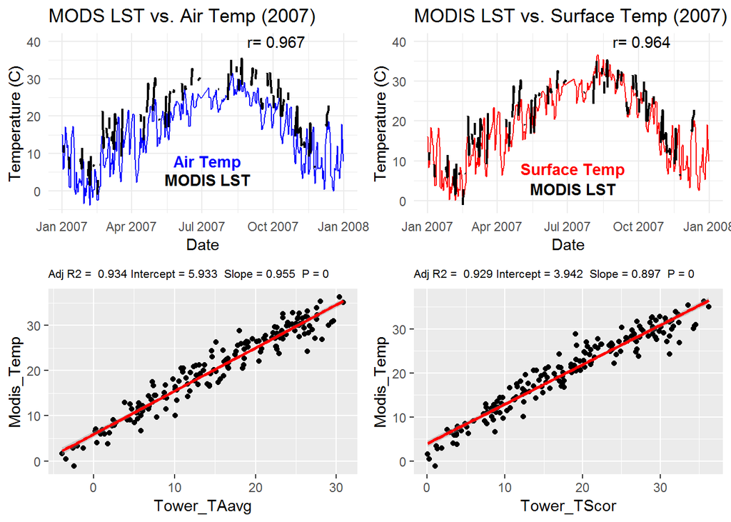